# Setting up the enviroment

### Importing relevant packages

```python
#Importing packages
import pandas as pd
import plotly.graph_objects as go
import plotly.express as px
import seaborn as sns
import matplotlib.pyplot as plt
import numpy as np
from scipy.stats import pearsonr
import warnings
from statsmodels.tsa.statespace.sarimax import SARIMAX
from sklearn.metrics import mean_squared_error
import statsmodels.api as sm
from statsmodels.tsa.arima.model import ARIMA
import itertools
```

### Reading the CSV file from the initial analysis

```python
# Read the CSV file into a DataFrame
trips_monthly = pd.read_csv('trips_monthly.csv')
trips_monthly.head()
```

|  | date_col | count |
| --- | --- | --- |
| 0 | 2018-01-01 | 3020192.0 |
| 1 | 2018-02-01 | 2968100.0 |
| 2 | 2018-03-01 | 3562090.0 |
| 3 | 2018-04-01 | 3685425.0 |
| 4 | 2018-05-01 | 3888148.0 |

```python
# Plot the original data with no 7-day moving average
fig = px.line(
    trips_monthly,
    x='date_col',
    y='count'
    )

fig.update_layout(
    title='Monthly Ridehail Trips',
    width=1400,
    xaxis=dict(
        title='Date',
        #tickformat='%Y-%m',  # Format for displaying year and month
        dtick='M3'
    ),
    yaxis=dict(
        title='Monthly Ridehail Trips'
    )
)

# Initial lockdown annotation
fig.add_shape(
    type='line',
    x0='2020-03-14',
    x1='2020-03-14',
    y0=0,
    y1=6300000,
    line=dict(
        color='red',
        width=2
    )
)
# Add annotation text
fig.add_annotation(
    x='2020-03-14',
    y=6000000,
    text='1st lockdown',
    showarrow=False,
    font=dict(
        color='red',
        size=12
    ),
    xanchor='left'
)

# Second lockdown annotation
fig.add_shape(
    type='line',
    x0='2020-11-23',
    x1='2020-11-23',
    y0=0,
    y1=6300000,
    line=dict(
        color='grey',
        width=2
    )
)
# Add annotation text
fig.add_annotation(
    x='2020-11-23',
    y=6000000,
    text='2nd lockdown',
    showarrow=False,
    font=dict(
        color='grey',
        size=12
    ),
    xanchor='left'
)

# Reopening annotation
fig.add_shape(
    type='line',
    x0='2021-06-11',
    x1='2021-06-11',
    y0=0,
    y1=6300000,
    line=dict(
        color='red',
        width=2
    )
)
# Add annotation text
fig.add_annotation(
    x='2021-06-11',
    y=6000000,
    text='Gradual reopening',
    showarrow=False,
    font=dict(
        color='red',
        size=12
    ),
    xanchor='left'
)

# Further limited travel orders annotation
fig.add_shape(
    type='line',
    x0='2022-01-05',
    x1='2022-01-05',
    y0=0,
    y1=6300000,
    line=dict(
        color='red',
        width=2
    )
)
# Add annotation text
fig.add_annotation(
    x='2022-01-05',
    y=6000000,
    text='Limited travel orders ',
    showarrow=False,
    font=dict(
        color='red',
        size=12
    ),
    xanchor='left'
)
fig.show()
```

# Removing observations during the lockdown periods

Observations from 2020-03 to 2022-02 were removed to determine if it improves the predictions. Months will be labelled instead not by the month, but by interval Month 1, Month 2 etc.

```python
trips_monthly = pd.DataFrame(trips_monthly)

# Convert the 'date_col' to datetime
trips_monthly['date_col'] = pd.to_datetime(trips_monthly['date_col'])

# Exclude rows between 2020-03-01 and 2022-02-01
trips_monthly = trips_monthly[~((trips_monthly['date_col'] >= '2020-03-01') & (trips_monthly['date_col'] <= '2022-02-01'))]

# Reset the index
trips_monthly.reset_index(drop=True, inplace=True)

# Add the 'month_interval' column
trips_monthly['month_interval'] = trips_monthly.index + 1

#Adds a new column called `month_reseq` so that the months are sequential
trips_monthly['month_reseq'] = trips_monthly['date_col']
trips_monthly.loc[trips_monthly['month_interval'] > 26, 'month_reseq'] -= pd.DateOffset(years=2)

# # Display the modified DataFrame
# trips_monthly
trips_monthly
```

|  | date_col | count | month_interval | month_reseq |
| --- | --- | --- | --- | --- |
| 0 | 2018-01-01 | 3020192.0 | 1 | 2018-01-01 |
| 1 | 2018-02-01 | 2968100.0 | 2 | 2018-02-01 |
| 2 | 2018-03-01 | 3562090.0 | 3 | 2018-03-01 |
| 3 | 2018-04-01 | 3685425.0 | 4 | 2018-04-01 |
| 4 | 2018-05-01 | 3888148.0 | 5 | 2018-05-01 |
| 5 | 2018-06-01 | 4213539.0 | 6 | 2018-06-01 |
| 6 | 2018-07-01 | 4185254.0 | 7 | 2018-07-01 |
| 7 | 2018-08-01 | 4783356.0 | 8 | 2018-08-01 |
| 8 | 2018-09-01 | 4994570.0 | 9 | 2018-09-01 |
| 9 | 2018-10-01 | 5196332.5 | 10 | 2018-10-01 |
| 10 | 2018-11-01 | 5384259.0 | 11 | 2018-11-01 |
| 11 | 2018-12-01 | 5480138.0 | 12 | 2018-12-01 |
| 12 | 2019-01-01 | 5304071.0 | 13 | 2019-01-01 |
| 13 | 2019-02-01 | 5112542.0 | 14 | 2019-02-01 |
| 14 | 2019-03-01 | 5768330.0 | 15 | 2019-03-01 |
| 15 | 2019-04-01 | 5402587.0 | 16 | 2019-04-01 |
| 16 | 2019-05-01 | 5690043.0 | 17 | 2019-05-01 |
| 17 | 2019-06-01 | 5665847.0 | 18 | 2019-06-01 |
| 18 | 2019-07-01 | 5289795.0 | 19 | 2019-07-01 |
| 19 | 2019-08-01 | 5549771.0 | 20 | 2019-08-01 |
| 20 | 2019-09-01 | 5514329.0 | 21 | 2019-09-01 |
| 21 | 2019-10-01 | 5776639.0 | 22 | 2019-10-01 |
| 22 | 2019-11-01 | 5980803.0 | 23 | 2019-11-01 |
| 23 | 2019-12-01 | 5959073.0 | 24 | 2019-12-01 |
| 24 | 2020-01-01 | 5551890.0 | 25 | 2020-01-01 |
| 25 | 2020-02-01 | 5678811.5 | 26 | 2020-02-01 |
| 26 | 2022-03-01 | 3547292.0 | 27 | 2020-03-01 |
| 27 | 2022-04-01 | 3499642.0 | 28 | 2020-04-01 |
| 28 | 2022-05-01 | 3688339.5 | 29 | 2020-05-01 |
| 29 | 2022-06-01 | 3943264.0 | 30 | 2020-06-01 |
| 30 | 2022-07-01 | 3988536.0 | 31 | 2020-07-01 |
| 31 | 2022-08-01 | 4108727.0 | 32 | 2020-08-01 |
| 32 | 2022-09-01 | 4252729.0 | 33 | 2020-09-01 |
| 33 | 2022-10-01 | 4355329.0 | 34 | 2020-10-01 |
| 34 | 2022-11-01 | 4260862.0 | 35 | 2020-11-01 |
| 35 | 2022-12-01 | 4638868.5 | 36 | 2020-12-01 |
| 36 | 2023-01-01 | 4083495.5 | 37 | 2021-01-01 |

```python
# Assuming you have the trips_monthly_t1 DataFrame
# Modify the DataFrame to include a combined label for rows with month_interval
trips_monthly['x_label'] = trips_monthly.apply(lambda row: f"{row['month_interval']} ({row['month_reseq'].strftime('%Y-%m')})"
                                                    if row['month_interval'] <= 26
                                                    else f"{row['month_interval']} ({row['date_col'].strftime('%Y-%m')})",
                                               axis=1)

# Create the line plot using Plotly Express
fig = px.line(trips_monthly, x='x_label', y='count')

# Update the x-axis tick mode to display all labels
fig.update_layout(xaxis={'type': 'category'})

fig.update_layout(
    title='Monthly Ridehail Trips',
    width=1400,
    xaxis=dict(
        title='Month Interval',
        #tickformat='%Y-%m',  # Format for displaying year and month
        dtick='M3'
    ),
    yaxis=dict(
        title='Monthly Ridehail Trips'
    )
)

# Shifted values to the right of this line
fig.add_shape(
    type='line',
    x0='25',
    x1='25',
    y0=0,
    y1=6300000,
    line=dict(
        color='red',
        width=2
    )
)
# Add annotation text
fig.add_annotation(
    x='25',
    y=6000000,
    text='Shifted values to the right of this line',
    showarrow=False,
    font=dict(
        color='red',
        size=12
    ),
    xanchor='left'
)

# Display the plot
fig.show()
```

```python
# Extract the year from the date_col
trips_monthly['year_col'] = trips_monthly['date_col'].dt.year

# Extract the month from the date_col
trips_monthly['month_col'] = trips_monthly['date_col'].dt.month

# Display the modified DataFrame
trips_monthly
```

|  | date_col | count | month_interval | month_reseq | x_label | year_col | month_col |
| --- | --- | --- | --- | --- | --- | --- | --- |
| 0 | 2018-01-01 | 3020192.0 | 1 | 2018-01-01 | 1 (2018-01) | 2018 | 1 |
| 1 | 2018-02-01 | 2968100.0 | 2 | 2018-02-01 | 2 (2018-02) | 2018 | 2 |
| 2 | 2018-03-01 | 3562090.0 | 3 | 2018-03-01 | 3 (2018-03) | 2018 | 3 |
| 3 | 2018-04-01 | 3685425.0 | 4 | 2018-04-01 | 4 (2018-04) | 2018 | 4 |
| 4 | 2018-05-01 | 3888148.0 | 5 | 2018-05-01 | 5 (2018-05) | 2018 | 5 |
| 5 | 2018-06-01 | 4213539.0 | 6 | 2018-06-01 | 6 (2018-06) | 2018 | 6 |
| 6 | 2018-07-01 | 4185254.0 | 7 | 2018-07-01 | 7 (2018-07) | 2018 | 7 |
| 7 | 2018-08-01 | 4783356.0 | 8 | 2018-08-01 | 8 (2018-08) | 2018 | 8 |
| 8 | 2018-09-01 | 4994570.0 | 9 | 2018-09-01 | 9 (2018-09) | 2018 | 9 |
| 9 | 2018-10-01 | 5196332.5 | 10 | 2018-10-01 | 10 (2018-10) | 2018 | 10 |
| 10 | 2018-11-01 | 5384259.0 | 11 | 2018-11-01 | 11 (2018-11) | 2018 | 11 |
| 11 | 2018-12-01 | 5480138.0 | 12 | 2018-12-01 | 12 (2018-12) | 2018 | 12 |
| 12 | 2019-01-01 | 5304071.0 | 13 | 2019-01-01 | 13 (2019-01) | 2019 | 1 |
| 13 | 2019-02-01 | 5112542.0 | 14 | 2019-02-01 | 14 (2019-02) | 2019 | 2 |
| 14 | 2019-03-01 | 5768330.0 | 15 | 2019-03-01 | 15 (2019-03) | 2019 | 3 |
| 15 | 2019-04-01 | 5402587.0 | 16 | 2019-04-01 | 16 (2019-04) | 2019 | 4 |
| 16 | 2019-05-01 | 5690043.0 | 17 | 2019-05-01 | 17 (2019-05) | 2019 | 5 |
| 17 | 2019-06-01 | 5665847.0 | 18 | 2019-06-01 | 18 (2019-06) | 2019 | 6 |
| 18 | 2019-07-01 | 5289795.0 | 19 | 2019-07-01 | 19 (2019-07) | 2019 | 7 |
| 19 | 2019-08-01 | 5549771.0 | 20 | 2019-08-01 | 20 (2019-08) | 2019 | 8 |
| 20 | 2019-09-01 | 5514329.0 | 21 | 2019-09-01 | 21 (2019-09) | 2019 | 9 |
| 21 | 2019-10-01 | 5776639.0 | 22 | 2019-10-01 | 22 (2019-10) | 2019 | 10 |
| 22 | 2019-11-01 | 5980803.0 | 23 | 2019-11-01 | 23 (2019-11) | 2019 | 11 |
| 23 | 2019-12-01 | 5959073.0 | 24 | 2019-12-01 | 24 (2019-12) | 2019 | 12 |
| 24 | 2020-01-01 | 5551890.0 | 25 | 2020-01-01 | 25 (2020-01) | 2020 | 1 |
| 25 | 2020-02-01 | 5678811.5 | 26 | 2020-02-01 | 26 (2020-02) | 2020 | 2 |
| 26 | 2022-03-01 | 3547292.0 | 27 | 2020-03-01 | 27 (2022-03) | 2022 | 3 |
| 27 | 2022-04-01 | 3499642.0 | 28 | 2020-04-01 | 28 (2022-04) | 2022 | 4 |
| 28 | 2022-05-01 | 3688339.5 | 29 | 2020-05-01 | 29 (2022-05) | 2022 | 5 |
| 29 | 2022-06-01 | 3943264.0 | 30 | 2020-06-01 | 30 (2022-06) | 2022 | 6 |
| 30 | 2022-07-01 | 3988536.0 | 31 | 2020-07-01 | 31 (2022-07) | 2022 | 7 |
| 31 | 2022-08-01 | 4108727.0 | 32 | 2020-08-01 | 32 (2022-08) | 2022 | 8 |
| 32 | 2022-09-01 | 4252729.0 | 33 | 2020-09-01 | 33 (2022-09) | 2022 | 9 |
| 33 | 2022-10-01 | 4355329.0 | 34 | 2020-10-01 | 34 (2022-10) | 2022 | 10 |
| 34 | 2022-11-01 | 4260862.0 | 35 | 2020-11-01 | 35 (2022-11) | 2022 | 11 |
| 35 | 2022-12-01 | 4638868.5 | 36 | 2020-12-01 | 36 (2022-12) | 2022 | 12 |
| 36 | 2023-01-01 | 4083495.5 | 37 | 2021-01-01 | 37 (2023-01) | 2023 | 1 |

# Correlation matrix of variables

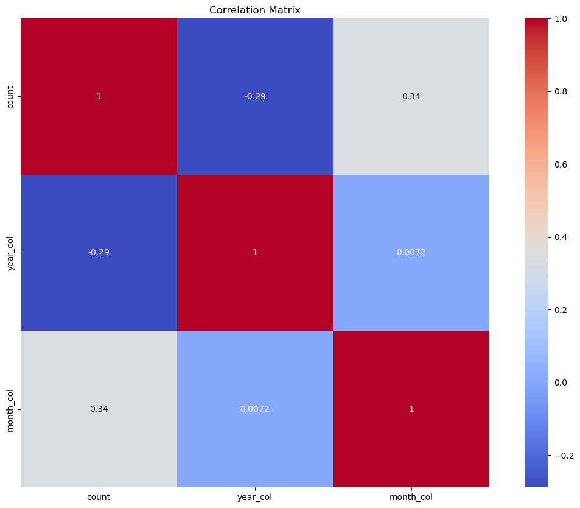

```python
warnings.filterwarnings('ignore') #Ignores warnings

trips_monthly_matrix = trips_monthly.loc[:, ['date_col', 'count', 'year_col', 'month_col']]

correlation_matrix = trips_monthly_matrix.corr()

# Create a heatmap
plt.figure(figsize=(15,10))
sns.heatmap(correlation_matrix, annot=True, cmap="coolwarm", square=True)

# Set the title and display the plot
plt.title('Correlation Matrix')
plt.show()
```

**Conclusions:**

With the explicit removal of values from 2020-03 to 2022-02, the correlations are similar the figures analyzed in the correlation matrices for Range 1 and Range 3-- as they should be.

# Time series forecasting

We will be splitting the dataset the same way, with a more condensed training dataset based on `date_col`

- Training dataset: January 2018 February 2020 and March 2022 to June 2022 (30 months)
- Testing from July 2022 to January 2023 (7 months)

```python
data = {
    'date_col': pd.to_datetime(trips_monthly['month_reseq']),
    'count': trips_monthly['count']
}

# Create a DataFrame with 'date_col' as the index
trips_monthly_df = pd.DataFrame(data).set_index('date_col')

# Split the dataset between train_set and test_set
train_set = trips_monthly_df[:30]
test_set = trips_monthly_df[30:]

trips_monthly_df.head()
```

| date_col | count |
| --- | --- |
| 2018-01-01 | 3020192.0 |
| 2018-02-01 | 2968100.0 |
| 2018-03-01 | 3562090.0 |
| 2018-04-01 | 3685425.0 |
| 2018-05-01 | 3888148.0 |

## Approach 1. Applying the ARIMA model

### Approach 1Ai. Using Root Mean Squared Error (RMSE) for all AR, I, MA combinations

The Root Mean Squared Error is a commonly used metric for evaluating the performance of a predictive model. It measures the average magnitude of the errors between the predicted values and the actual values of a target variable. The lower the RMSE, the better.

```python
# Identifies the typical ranges of p (autoregressive order), d (integrated order), q (moving average order)
p=range(0,12) #Typically values from 0 to 12
d=range(0,2)  #Typically values from 0 to 2
q=range(0,10)  #Typically values from 0 to 10

pdq_combination = list(itertools.product(p,d,q))
#Create empty lists for RMSE and Order
rmse=[]
order=[]

for pdq in pdq_combination:
    try:
        model = ARIMA(train_set, order=pdq).fit()
        prediction = model.predict(start=len(train_set), end=(len(trips_monthly_df)-1))
        error = np.sqrt(mean_squared_error(test_set, prediction, squared=False))
        order.append(pdq)
        rmse.append(error)
    except:
        continue
#Sorts the RMSE outputs from smallest to highest for each combination of b, q, d
results = pd.DataFrame(index=order, data=rmse, columns=['RMSE']).sort_values(by='RMSE', ascending=True)
results
```

|  | RMSE |
| --- | --- |
| (1, 0, 0) | 412.108763 |
| (2, 0, 1) | 413.269384 |
| (1, 0, 1) | 413.364448 |
| (2, 0, 0) | 413.624117 |
| (0, 1, 4) | 458.595895 |
| ... | ... |
| (6, 0, 6) | 2035.096871 |
| (10, 1, 5) | 2060.558036 |
| (6, 1, 6) | 2209.767435 |
| (6, 0, 7) | 2934.455913 |
| (11, 1, 6) | 34379.777059 |

189 rows × 1 columns

```python
warnings.filterwarnings('ignore') #Ignores warnings

#Predicting demand in the test range period
model = ARIMA(train_set, order=(1, 0, 0))
model_fit = model.fit()
prediction = model_fit.predict(start=len(train_set), end=(len(trips_monthly_df)-1))

model_fit.summary()
```

SARIMAX Results

| Dep. Variable: | count | No. Observations: | 30 |
| --- | --- | --- | --- |
| Model: | ARIMA(1, 0, 0) | Log Likelihood | -435.667 |
| Date: | Tue, 18 Jul 2023 | AIC | 877.333 |
| Time: | 12:50:40 | BIC | 881.537 |
| Sample: | 01-01-2018 | HQIC | 878.678 |
|  | - 06-01-2020 |  |  |
| Covariance Type: | opg |  |  |

|  | coef | std err | z | P>\|z\| | [0.025 | 0.975] |
| --- | --- | --- | --- | --- | --- | --- |
| const | 4.809e+06 | 4.83e+05 | 9.965 | 0.000 | 3.86e+06 | 5.76e+06 |
| ar.L1 | 0.8945 | 0.074 | 12.126 | 0.000 | 0.750 | 1.039 |
| sigma2 | 2.079e+11 | 7.661 | 2.71e+10 | 0.000 | 2.08e+11 | 2.08e+11 |

| Ljung-Box (L1) (Q): | 0.02 | Jarque-Bera (JB): | 132.71 |
| --- | --- | --- | --- |
| Prob(Q): | 0.90 | Prob(JB): | 0.00 |
| Heteroskedasticity (H): | 3.50 | Skew: | -2.62 |
| Prob(H) (two-sided): | 0.06 | Kurtosis: | 11.88 |

Warnings:  
[1] Covariance matrix calculated using the outer product of gradients (complex-step).  
[2] Covariance matrix is singular or near-singular, with condition number 2.02e+25. Standard errors may be unstable.

```python
# Assign the index name and rename it as `date_col`
prediction.index = pd.to_datetime(prediction.index).rename('date_col')

# Calculate MSE
mse = np.mean((np.array(test_set) - np.array(prediction))**2)

# Calculate RMSE
rmse = np.sqrt(mse)

# Calculate MAE
mae = np.mean(np.abs(np.array(test_set) - np.array(prediction)))

print("RMSE:", rmse)
print("MSE:", mse)
print("MAE:", mae)
```

```
RMSE: 235765.1008148742
MSE: 55585182762.24779
MAE: 189221.16002160424
```

```python
mean_val = test_set.mean().item()
stdev = np.sqrt(test_set.var()).item()

print('Mean: %F'  % mean_val)
print('Standard deviation: %F' % stdev)

# print('ADF Statistic: %F' % result[0])
# print('p-value: %F' % result[1])

#Determining the mean squared error
error = np.sqrt(mean_squared_error(test_set, prediction))
print('Error: %F'  % error)
```

[output not shown]

**Conclusion**

**Graphing the predictions in the test set period**

```python
## Setting up the table to graph
# Concatenate train_set, test_set, and predictions into a single DataFrame
data = pd.concat([train_set, test_set, prediction], axis=1)
data.columns = ['Train Set', 'Test Set', 'ARIMA Prediction']

# Reset the index
data = data.reset_index()

# Convert the 'date_col' to datetime
data['date_col'] = pd.to_datetime(data['date_col'])

# Add the 'month_interval' column
data['month_interval'] = data.index + 1

# Calculate the next month by adding one month to the previous row
data['month_deseq'] = data['date_col'].apply(lambda x: x if x <= pd.Timestamp('2020-02-01') else x + pd.DateOffset(years=2))

# Modify the DataFrame to include a combined label for rows with month_interval
data['x_label'] = data.apply(lambda row: f"{row['month_interval']} ({row['month_deseq'].strftime('%Y-%m')})" if pd.notnull(row['month_deseq'])
                         else f"{row['month_interval']}", axis=1)

# Display the modified DataFrame
data.head()
```

|  | date_col | Train Set | Test Set | ARIMA Prediction | month_interval | month_deseq | x_label |
| --- | --- | --- | --- | --- | --- | --- | --- |
| 0 | 2018-01-01 | 3020192.0 | NaN | NaN | 1 | 2018-01-01 | 1 (2018-01) |
| 1 | 2018-02-01 | 2968100.0 | NaN | NaN | 2 | 2018-02-01 | 2 (2018-02) |
| 2 | 2018-03-01 | 3562090.0 | NaN | NaN | 3 | 2018-03-01 | 3 (2018-03) |
| 3 | 2018-04-01 | 3685425.0 | NaN | NaN | 4 | 2018-04-01 | 4 (2018-04) |
| 4 | 2018-05-01 | 3888148.0 | NaN | NaN | 5 | 2018-05-01 | 5 (2018-05) |

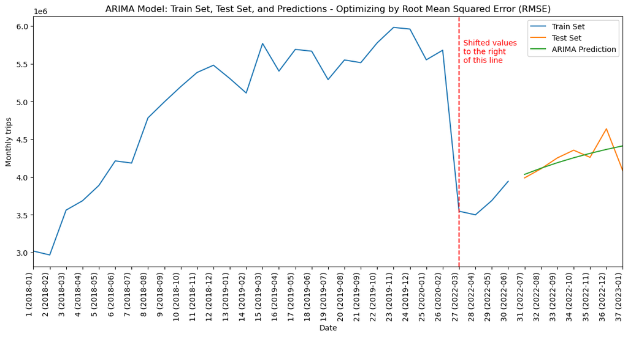

```python
# Identify plot size
fig, ax = plt.subplots(figsize=(14, 6))

# Plot the lines
ax.plot(data['x_label'], data['Train Set'], label='Train Set')
ax.plot(data['x_label'], data['Test Set'], label='Test Set')
ax.plot(data['x_label'], data['ARIMA Prediction'], label='ARIMA Prediction')

# Set x-axis label, y-axis label, and title
ax.set_xlabel('Date')
ax.set_ylabel('Monthly trips')
ax.set_title('ARIMA Model: Train Set, Test Set, and Predictions - Optimizing by Root Mean Squared Error (RMSE)')

# Add legend
ax.legend()

plt.xticks(rotation=90, ha='right')  # Rotate and slant x-axis labels to the right

# Add a vertical line
ax.axvline(x=26, color='red', linestyle='--')

# Add label for the vertical line
ax.text(26.25, ax.get_ylim()[1]- 0.05 * ax.get_ylim()[1], 'Shifted values\nto the right\nof this line',
        color='red', verticalalignment='top', horizontalalignment='left')

# Adjust spacing before the first tick and after the last tick
plt.margins(x=0)

plt.show()
```

**Commentary of the ARIMA Prediction**

The ARIMA prediction above fit the observed values fairly well. There is a general smoothing with this ARIMA prediction compared with the full dataset (without the removal of pandemic observations).

**Graphing the predictions in the period beyond training set**

```python
warnings.filterwarnings('ignore') #Ignores warnings

final_model = ARIMA(train_set, order=(1,0,0)).fit()
prediction_future = final_model.predict(len(train_set), len(train_set) + 12) # Build the ARIMA model beyond the available data
```

```python
## Setting up the table to graph
# Concatenate train_set, test_set, and predictions into a single DataFrame
data = pd.concat([train_set, prediction_future], axis=1)
data.columns = ['Observed', 'Prediction']

data.reset_index(drop=False, inplace=True)

data = data.rename(columns={'index': 'date_col'})

# Convert the 'date_col' to datetime
data['date_col'] = pd.to_datetime(data['date_col'])

# Add the 'month_interval' column
data['month_interval'] = data.index + 1

# Calculate the next month by adding one month to the previous row
data['month_deseq'] = data['date_col'].apply(lambda x: x if x <= pd.Timestamp('2020-02-01') else x + pd.DateOffset(years=2))

# Modify the DataFrame to include a combined label for rows with month_interval
data['x_label'] = data.apply(lambda row: f"{row['month_interval']} ({row['month_deseq'].strftime('%Y-%m')})" if pd.notnull(row['month_deseq'])
                         else f"{row['month_interval']}", axis=1)

# Display the modified DataFrame
data.head()
```

|  | date_col | Observed | Prediction | month_interval | month_deseq | x_label |
| --- | --- | --- | --- | --- | --- | --- |
| 0 | 2018-01-01 | 3020192.0 | NaN | 1 | 2018-01-01 | 1 (2018-01) |
| 1 | 2018-02-01 | 2968100.0 | NaN | 2 | 2018-02-01 | 2 (2018-02) |
| 2 | 2018-03-01 | 3562090.0 | NaN | 3 | 2018-03-01 | 3 (2018-03) |
| 3 | 2018-04-01 | 3685425.0 | NaN | 4 | 2018-04-01 | 4 (2018-04) |
| 4 | 2018-05-01 | 3888148.0 | NaN | 5 | 2018-05-01 | 5 (2018-05) |

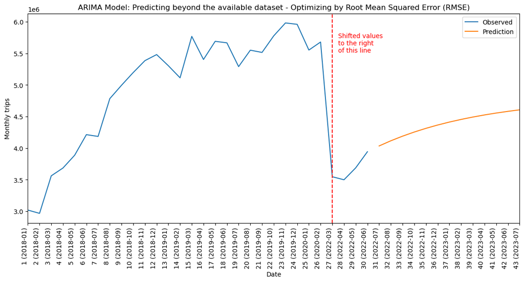

```python
# Identify plot size
fig, ax = plt.subplots(figsize=(14, 6))

# Plot the lines
ax.plot(data['x_label'], data['Observed'], label='Observed')
ax.plot(data['x_label'], data['Prediction'], label='Prediction')

# Set x-axis label, y-axis label, and title
ax.set_xlabel('Date')
ax.set_ylabel('Monthly trips')
ax.set_title('ARIMA Model: Predicting beyond the available dataset - Optimizing by Root Mean Squared Error (RMSE)')

# Add legend
ax.legend()

plt.xticks(rotation=90, ha='right')  # Rotate and slant x-axis labels to the right

# Add a vertical line
ax.axvline(x=26, color='red', linestyle='--')

# Add label for the vertical line
ax.text(26.5, ax.get_ylim()[1]- 0.05 * ax.get_ylim()[1], 'Shifted values\nto the right\nof this line',
        color='red', verticalalignment='top', horizontalalignment='left')

# Adjust spacing before the first tick and after the last tick
plt.margins(x=0)

plt.show()
```

**Commentary of the ARIMA prediction beyond the test set**

The prediction beyond the test set using the same modelling parameters a steady increase

### Approach 1Bi. Using Bayesian Information Criterion (BIC) for all AR, I, MA combinations

Information criteria, such as the Akaike Information Criterion (AIC) or the Bayesian Information Criterion (BIC), can be used to compare different ARIMA models. Lower values of AIC or BIC indicate a better fit, considering both the model's goodness of fit and its complexity.

- AIC is suitable when the emphasis is on finding the best predictive model, even if it is more complex.
- BIC is more appropriate when the emphasis is on finding a simpler model with good predictive performance and avoiding overfitting.

Based on these conditions, BIC is more appropriate in this case that balances performance without overfitting.

```python
warnings.filterwarnings('ignore') #Ignores warnings

# Identifies the typical ranges of p (autoregressive order), q (moving average order), d (integrated order)

pdq_combination.clear()
order.clear()

p = range(0, 12)
q = range(0, 10)
d = range(0, 2)

pdq_combination = list(itertools.product(p, d, q))

# Create empty lists for BIC
bic = []

# For loop that calculates the BIC for each combination
for pdq in pdq_combination:
    try:
        model = ARIMA(train_set, order=pdq).fit()
        bic_value = model.bic
        order.append(pdq)
        bic.append(bic_value)
    except:
        continue

# Sort the BIC values from smallest to highest for each combination of p, d, q
results = pd.DataFrame(index=order, data=bic, columns=['BIC']).sort_values(by='BIC', ascending=True)
results
```

|  | BIC |
| --- | --- |
| (10, 1, 5) | 5.387673e+01 |
| (11, 1, 6) | 1.013425e+02 |
| (11, 1, 7) | 1.026197e+02 |
| (0, 1, 0) | 8.452191e+02 |
| (1, 1, 0) | 8.485156e+02 |
| ... | ... |
| (6, 0, 7) | 1.945390e+09 |
| (0, 0, 8) | NaN |
| (0, 0, 9) | NaN |
| (0, 1, 8) | NaN |
| (0, 1, 9) | NaN |

193 rows × 1 columns

```python
warnings.filterwarnings('ignore') #Ignores warnings

#Predicting demand in the test range period
model = ARIMA(train_set, order=(10, 1, 5))
model_fit = model.fit()

prediction = model_fit.predict(start=len(train_set), end=(len(trips_monthly_df)-1))
model_fit.summary()
```

SARIMAX Results

| Dep. Variable: | count | No. Observations: | 30 |
| --- | --- | --- | --- |
| Model: | ARIMA(10, 1, 5) | Log Likelihood | 0.000 |
| Date: | Tue, 18 Jul 2023 | AIC | 32.000 |
| Time: | 17:02:00 | BIC | 53.877 |
| Sample: | 01-01-2018 | HQIC | 38.852 |
|  | - 06-01-2020 |  |  |
| Covariance Type: | opg |  |  |

|  | coef | std err | z | P>\|z\| | [0.025 | 0.975] |
| --- | --- | --- | --- | --- | --- | --- |
| ar.L1 | -0.9859 | 5.86e-11 | -1.68e+10 | 0.000 | -0.986 | -0.986 |
| ar.L2 | 2.8563 | 4.39e-13 | 6.51e+12 | 0.000 | 2.856 | 2.856 |
| ar.L3 | 4.1362 | 2.06e-14 | 2.01e+14 | 0.000 | 4.136 | 4.136 |
| ar.L4 | -1.8567 | 2.73e-12 | -6.8e+11 | 0.000 | -1.857 | -1.857 |
| ar.L5 | -6.2985 | 4.64e-09 | -1.36e+09 | 0.000 | -6.299 | -6.299 |
| ar.L6 | -1.8581 | 3.65e-13 | -5.09e+12 | 0.000 | -1.858 | -1.858 |
| ar.L7 | 4.1352 | 4.55e-13 | 9.08e+12 | 0.000 | 4.135 | 4.135 |
| ar.L8 | 2.8565 | 4.4e-14 | 6.49e+13 | 0.000 | 2.857 | 2.857 |
| ar.L9 | -0.9853 | 4.94e-13 | -1.99e+12 | 0.000 | -0.985 | -0.985 |
| ar.L10 | -0.9998 | 1.72e-14 | -5.83e+13 | 0.000 | -1.000 | -1.000 |
| ma.L1 | 2.3590 | -0 | -inf | 0.000 | 2.359 | 2.359 |
| ma.L2 | 1.3620 | -0 | -inf | 0.000 | 1.362 | 1.362 |
| ma.L3 | -1.3624 | -0 | inf | 0.000 | -1.362 | -1.362 |
| ma.L4 | -2.3588 | 7.75e-08 | -3.04e+07 | 0.000 | -2.359 | -2.359 |
| ma.L5 | -0.9998 | -0 | inf | 0.000 | -1.000 | -1.000 |
| sigma2 | 7.182e+04 | -0 | -inf | 0.000 | 7.18e+04 | 7.18e+04 |

| Ljung-Box (L1) (Q): | nan | Jarque-Bera (JB): | nan |
| --- | --- | --- | --- |
| Prob(Q): | nan | Prob(JB): | nan |
| Heteroskedasticity (H): | nan | Skew: | nan |
| Prob(H) (two-sided): | nan | Kurtosis: | nan |

Warnings:  
[1] Covariance matrix calculated using the outer product of gradients (complex-step).  
[2] Covariance matrix is singular or near-singular, with condition number inf. Standard errors may be unstable.

```python
# Assign the index name and rename it as `date_col`
prediction.index = pd.to_datetime(prediction.index).rename('date_col')

# Calculate MSE
mse = np.mean((np.array(test_set) - np.array(prediction))**2)

# Calculate RMSE
rmse = np.sqrt(mse)

# Calculate MAE
mae = np.mean(np.abs(np.array(test_set) - np.array(prediction)))

print("RMSE:", rmse)
print("MSE:", mse)
print("MAE:", mae)
```

```
RMSE: 4245899.417948763
MSE: 18027661867337.645
MAE: 4241221.0
```

```python
#Model evaluation
mean_val = test_set.mean().item()
stdev = np.sqrt(test_set.var()).item()

print('Mean: %F'  % mean_val)
print('Standard deviation: %F' % stdev)

# print('ADF Statistic: %F' % result[0])
# print('p-value: %F' % result[1])

#Determining the mean squared error
error = np.sqrt(mean_squared_error(test_set, prediction))
print('Error: %F'  % error)
```

```
Mean: 4241221.000000
Standard deviation: 215230.138641
Error: 4245899.417949
```

**Conclusion**

The standard error is exceptionally large, compared with the identified standard devivation. This is a good indicator that it is not a good fit.

**Graphing the predictions in the test set period**

```python
## Setting up the table to graph
# Concatenate train_set, test_set, and predictions into a single DataFrame
data = pd.concat([train_set, test_set, prediction], axis=1)
data.columns = ['Train Set', 'Test Set', 'ARIMA Prediction']

# Reset the index
data = data.reset_index()

# Convert the 'date_col' to datetime
data['date_col'] = pd.to_datetime(data['date_col'])

# Add the 'month_interval' column
data['month_interval'] = data.index + 1

# Calculate the next month by adding one month to the previous row
data['month_deseq'] = data['date_col'].apply(lambda x: x if x <= pd.Timestamp('2020-02-01') else x + pd.DateOffset(years=2))

# Modify the DataFrame to include a combined label for rows with month_interval
data['x_label'] = data.apply(lambda row: f"{row['month_interval']} ({row['month_deseq'].strftime('%Y-%m')})" if pd.notnull(row['month_deseq'])
                         else f"{row['month_interval']}", axis=1)

# Display the modified DataFrame
data.head()
```

|  | date_col | Train Set | Test Set | ARIMA Prediction | month_interval | month_deseq | x_label |
| --- | --- | --- | --- | --- | --- | --- | --- |
| 0 | 2018-01-01 | 3020192.0 | NaN | NaN | 1 | 2018-01-01 | 1 (2018-01) |
| 1 | 2018-02-01 | 2968100.0 | NaN | NaN | 2 | 2018-02-01 | 2 (2018-02) |
| 2 | 2018-03-01 | 3562090.0 | NaN | NaN | 3 | 2018-03-01 | 3 (2018-03) |
| 3 | 2018-04-01 | 3685425.0 | NaN | NaN | 4 | 2018-04-01 | 4 (2018-04) |
| 4 | 2018-05-01 | 3888148.0 | NaN | NaN | 5 | 2018-05-01 | 5 (2018-05) |

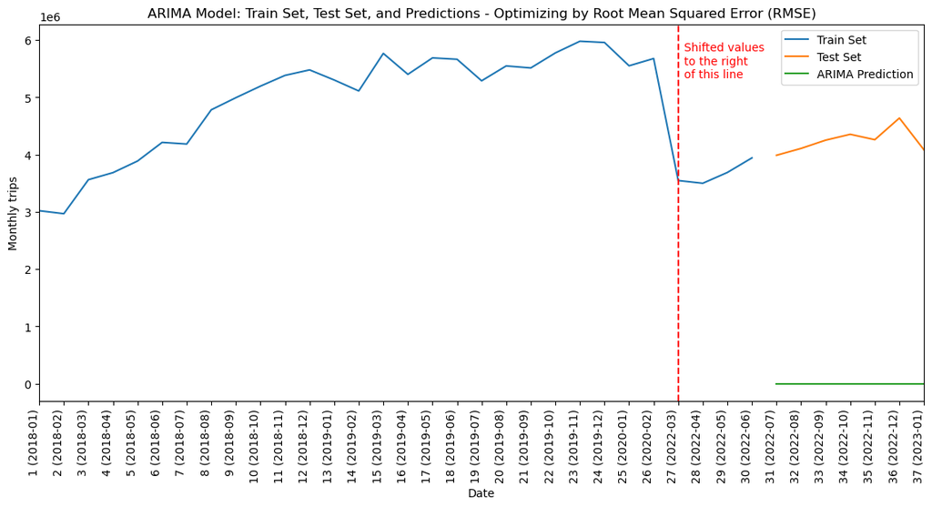

```python
# Identify plot size
fig, ax = plt.subplots(figsize=(14, 6))

# Plot the lines
ax.plot(data['x_label'], data['Train Set'], label='Train Set')
ax.plot(data['x_label'], data['Test Set'], label='Test Set')
ax.plot(data['x_label'], data['ARIMA Prediction'], label='ARIMA Prediction')

# Set x-axis label, y-axis label, and title
ax.set_xlabel('Date')
ax.set_ylabel('Monthly trips')
ax.set_title('ARIMA Model: Train Set, Test Set, and Predictions - Optimizing by Root Mean Squared Error (RMSE)')

# Add legend
ax.legend()

plt.xticks(rotation=90, ha='right')  # Rotate and slant x-axis labels to the right

# Add a vertical line
ax.axvline(x=26, color='red', linestyle='--')

# Add label for the vertical line
ax.text(26.25, ax.get_ylim()[1]- 0.05 * ax.get_ylim()[1], 'Shifted values\nto the right\nof this line',
        color='red', verticalalignment='top', horizontalalignment='left')

# Adjust spacing before the first tick and after the last tick
plt.margins(x=0)

plt.show()
```

**Commentary of the ARIMA Prediction**

```python
warnings.filterwarnings('ignore') #Ignores warnings

final_model = ARIMA(train_set, order=(10,1,5)).fit()  # Build the ARIMA model beyond the available data
prediction_future = final_model.predict(len(train_set), len(train_set) + 12)
```

```python
## Setting up the table to graph
# Concatenate train_set, test_set, and predictions into a single DataFrame
data = pd.concat([train_set, prediction_future], axis=1)
data.columns = ['Observed', 'Prediction']


# Reset the index
data = data.reset_index()
data = data.rename(columns={'index': 'date_col'})

# Convert the 'date_col' to datetime
data['date_col'] = pd.to_datetime(data['date_col'])

# Add the 'month_interval' column
data['month_interval'] = data.index + 1

# Calculate the next month by adding one month to the previous row
data['month_deseq'] = data['date_col'].apply(lambda x: x if x <= pd.Timestamp('2020-02-01') else x + pd.DateOffset(years=2))

# Modify the DataFrame to include a combined label for rows with month_interval
data['x_label'] = data.apply(lambda row: f"{row['month_interval']} ({row['month_deseq'].strftime('%Y-%m')})" if pd.notnull(row['month_deseq'])
                         else f"{row['month_interval']}", axis=1)

# Display the modified DataFrame
data.head()
```

|  | date_col | Observed | Prediction | month_interval | month_deseq | x_label |
| --- | --- | --- | --- | --- | --- | --- |
| 0 | 2018-01-01 | 3020192.0 | NaN | 1 | 2018-01-01 | 1 (2018-01) |
| 1 | 2018-02-01 | 2968100.0 | NaN | 2 | 2018-02-01 | 2 (2018-02) |
| 2 | 2018-03-01 | 3562090.0 | NaN | 3 | 2018-03-01 | 3 (2018-03) |
| 3 | 2018-04-01 | 3685425.0 | NaN | 4 | 2018-04-01 | 4 (2018-04) |
| 4 | 2018-05-01 | 3888148.0 | NaN | 5 | 2018-05-01 | 5 (2018-05) |

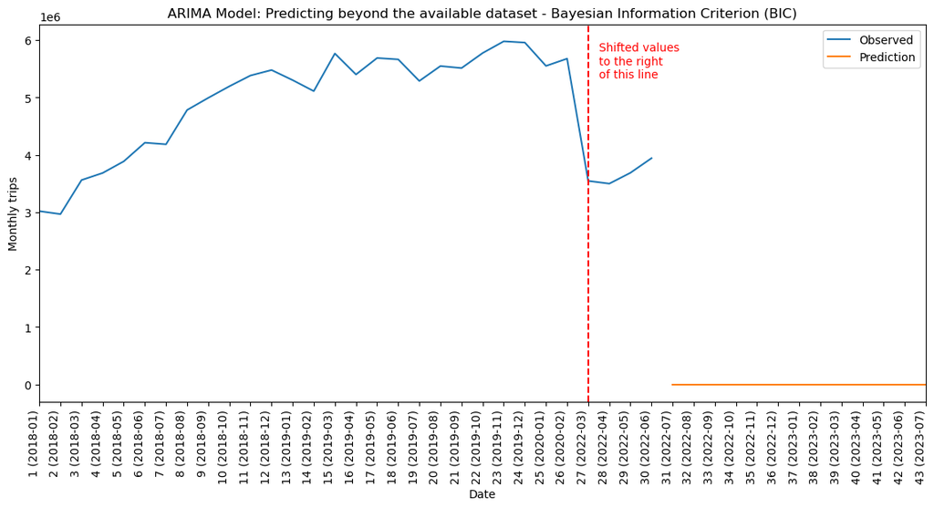

```python
# Identify plot size
fig, ax = plt.subplots(figsize=(14, 6))

# Plot the lines
ax.plot(data['x_label'], data['Observed'], label='Observed')
ax.plot(data['x_label'], data['Prediction'], label='Prediction')

# Set x-axis label, y-axis label, and title
ax.set_xlabel('Date')
ax.set_ylabel('Monthly trips')
ax.set_title('ARIMA Model: Predicting beyond the available dataset - Bayesian Information Criterion (BIC)')

# Add legend
ax.legend()

plt.xticks(rotation=90, ha='right')  # Rotate and slant x-axis labels to the right

# Add a vertical line
ax.axvline(x=26, color='red', linestyle='--')

# Add label for the vertical line
ax.text(26.5, ax.get_ylim()[1]- 0.05 * ax.get_ylim()[1], 'Shifted values\nto the right\nof this line',
        color='red', verticalalignment='top', horizontalalignment='left')

# Adjust spacing before the first tick and after the last tick
plt.margins(x=0)

plt.show()
```

**Commentary of the ARIMA prediction beyond the test set**

## Approach 2. Applying the SARIMA model

### Determining the SARIMA hyperparameters

### Approach 2Ai. Optimizing for Root Mean Squared Error (RMSE) for all AR, I, MA combinations

```python
# %%script false # Skips running this code due to long runtime

# Identifies the typical ranges of p (autoregressive order), q (moving average order), d (integrated order)
pdq_combination.clear()

# Identifies the typical ranges of p (autoregressive order), d (integrated order), q (moving average order)
p=range(0,12) #Typically values from 0 to 12
d=range(0,2)  #Typically values from 0 to 2
q=range(0,10)  #Typically values from 0 to 10
s = 12

pdq_combination = list(itertools.product(p,d,q))
```

```python
# %%script false # Skips running this code due to long runtime
# warnings.filterwarnings('ignore') #Ignores warnings

#Create empty lists for RMSE and Order
rmse=[]
order=[]

#For loop that calculates the mean squared error for each

for pdq in pdq_combination:
    try:
        model = SARIMAX(train_set, order=(1, 0, 0), seasonal_order=(*pdq, s)).fit()
        prediction = model.predict(start = len(train_set),end = len(trips_monthly_df)-1)
        error = np.sqrt(mean_squared_error(test_set, prediction))
        order.append(pdq)
        rmse.append(error)
    except:
        continue
```

```python
# %%script false # Skips running this code due to long runtime

#Sorts the RMSE outputs from smallest to highest for each combination of b, q, d
results_rmse_add = pd.DataFrame(index=order, data=rmse, columns=['RMSE']).sort_values(by='RMSE', ascending=True)
results_rmse_add
```

|  | RMSE |
| --- | --- |
| (1, 1, 1) | 4.462409e+05 |
| (0, 1, 2) | 4.779830e+05 |
| (1, 0, 0) | 4.829472e+05 |
| (0, 0, 0) | 4.851478e+05 |
| (1, 1, 2) | 5.053957e+05 |
| ... | ... |
| (8, 0, 0) | 7.224942e+05 |
| (11, 0, 0) | 7.226141e+05 |
| (0, 1, 0) | 1.048748e+06 |
| (1, 1, 0) | 1.054334e+06 |
| (0, 1, 1) | 1.061475e+06 |

240 rows × 1 columns

```python
# %%script false # Skips running this code due to long runtime

# #Exported the table due to the long time needed to determine the BIC values for all B, Q, D values
results_rmse_add.reset_index().to_csv('rmse_results_wremoval.csv', index=False) #RMSE for loop results
```

```python
# Read the CSV file into a DataFrame
results_rmse_add = pd.read_csv('rmse_results_wremoval.csv')
results_rmse_add
```

|  | index | RMSE |
| --- | --- | --- |
| 0 | (1, 1, 1) | 4.462409e+05 |
| 1 | (0, 1, 2) | 4.779830e+05 |
| 2 | (1, 0, 0) | 4.829472e+05 |
| 3 | (0, 0, 0) | 4.851478e+05 |
| 4 | (1, 1, 2) | 5.053957e+05 |
| ... | ... | ... |
| 235 | (8, 0, 0) | 7.224942e+05 |
| 236 | (11, 0, 0) | 7.226141e+05 |
| 237 | (0, 1, 0) | 1.048748e+06 |
| 238 | (1, 1, 0) | 1.054334e+06 |
| 239 | (0, 1, 1) | 1.061475e+06 |

240 rows × 2 columns

```python
arima_order = (1, 0, 0) #Based on the ARIMA optimization above
sarima_order = (1, 1, 1, 12)
sarima_model_fit = SARIMAX(train_set, order=arima_order, seasonal_order=sarima_order).fit()
sarima_model_fit.summary()
```

SARIMAX Results

| Dep. Variable: | count | No. Observations: | 30 |
| --- | --- | --- | --- |
| Model: | SARIMAX(1, 0, 0)x(1, 1, [1], 12) | Log Likelihood | -269.701 |
| Date: | Tue, 18 Jul 2023 | AIC | 547.402 |
| Time: | 16:58:32 | BIC | 550.963 |
| Sample: | 01-01-2018 | HQIC | 547.893 |
|  | - 06-01-2020 |  |  |
| Covariance Type: | opg |  |  |

|  | coef | std err | z | P>\|z\| | [0.025 | 0.975] |
| --- | --- | --- | --- | --- | --- | --- |
| ar.L1 | 0.7091 | 0.095 | 7.481 | 0.000 | 0.523 | 0.895 |
| ar.S.L12 | 0.7546 | 0.455 | 1.660 | 0.097 | -0.137 | 1.646 |
| ma.S.L12 | -0.9998 | 0.547 | -1.827 | 0.068 | -2.072 | 0.073 |
| sigma2 | 4.725e+11 | 1.16e-12 | 4.07e+23 | 0.000 | 4.72e+11 | 4.72e+11 |

| Ljung-Box (L1) (Q): | 0.00 | Jarque-Bera (JB): | 18.89 |
| --- | --- | --- | --- |
| Prob(Q): | 0.95 | Prob(JB): | 0.00 |
| Heteroskedasticity (H): | 1.61 | Skew: | -1.92 |
| Prob(H) (two-sided): | 0.58 | Kurtosis: | 6.23 |

Warnings:  
[1] Covariance matrix calculated using the outer product of gradients (complex-step).  
[2] Covariance matrix is singular or near-singular, with condition number 8.76e+39. Standard errors may be unstable.

**Interpretation**

**Predicting using the model**

```python
prediction = pd.DataFrame(sarima_model_fit.forecast(len(test_set)))

# Assign the index name and rename it as `date_col`
prediction.index = pd.to_datetime(prediction.index).rename('date_col')

# Display the DataFrame with the assigned index
prediction
```

| date_col | predicted_mean |
| --- | --- |
| 2020-07-01 | 3.906081e+06 |
| 2020-08-01 | 4.342590e+06 |
| 2020-09-01 | 4.444298e+06 |
| 2020-10-01 | 4.748884e+06 |
| 2020-11-01 | 4.957420e+06 |
| 2020-12-01 | 4.926124e+06 |
| 2021-01-01 | 4.840551e+06 |

```python
# Calculate MSE
mse = np.mean((np.array(test_set) - np.array(prediction))**2)

# Calculate RMSE
rmse = np.sqrt(mse)

# Calculate MAE
mae = np.mean(np.abs(np.array(test_set) - np.array(prediction)))

print("RMSE:", rmse)
print("MSE:", mse)
print("MAE:", mae)
```

```
RMSE: 446240.9003973588
MSE: 199130941187.44553
MAE: 377472.918168757
```

```python
mean_val = test_set.mean().item()
stdev = np.sqrt(test_set.var()).item()

print('Mean: %F'  % mean_val)
print('Standard deviation: %F' % stdev)

# print('ADF Statistic: %F' % result[0])
# print('p-value: %F' % result[1])

#Determining the mean squared error
error = np.sqrt(mean_squared_error(test_set, prediction))
print('Error: %F'  % error)
```

```
Mean: 4241221.000000
Standard deviation: 215230.138641
Error: 446240.900397
```

**Graphing the predictions in the test set period**

```python
## Setting up the table to graph
# Concatenate train_set, test_set, and predictions into a single DataFrame
data = pd.concat([train_set, test_set, prediction], axis=1)
data.columns = ['Train Set', 'Test Set', 'SARIMA Prediction']

# Reset the index
data = data.reset_index()

# Convert the 'date_col' to datetime
data['date_col'] = pd.to_datetime(data['date_col'])

# Add the 'month_interval' column
data['month_interval'] = data.index + 1

# Calculate the next month by adding one month to the previous row
data['month_deseq'] = data['date_col'].apply(lambda x: x if x <= pd.Timestamp('2020-02-01') else x + pd.DateOffset(years=2))

# Modify the DataFrame to include a combined label for rows with month_interval
data['x_label'] = data.apply(lambda row: f"{row['month_interval']} ({row['month_deseq'].strftime('%Y-%m')})" if pd.notnull(row['month_deseq'])
                         else f"{row['month_interval']}", axis=1)

# Display the modified DataFrame
data.head()
```

|  | date_col | Train Set | Test Set | SARIMA Prediction | month_interval | month_deseq | x_label |
| --- | --- | --- | --- | --- | --- | --- | --- |
| 0 | 2018-01-01 | 3020192.0 | NaN | NaN | 1 | 2018-01-01 | 1 (2018-01) |
| 1 | 2018-02-01 | 2968100.0 | NaN | NaN | 2 | 2018-02-01 | 2 (2018-02) |
| 2 | 2018-03-01 | 3562090.0 | NaN | NaN | 3 | 2018-03-01 | 3 (2018-03) |
| 3 | 2018-04-01 | 3685425.0 | NaN | NaN | 4 | 2018-04-01 | 4 (2018-04) |
| 4 | 2018-05-01 | 3888148.0 | NaN | NaN | 5 | 2018-05-01 | 5 (2018-05) |

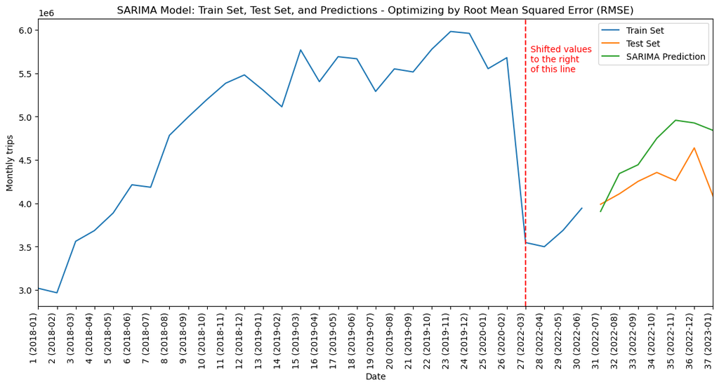

```python
# Identify plot size
fig, ax = plt.subplots(figsize=(14, 6))

# Plot the lines
ax.plot(data['x_label'], data['Train Set'], label='Train Set')
ax.plot(data['x_label'], data['Test Set'], label='Test Set')
ax.plot(data['x_label'], data['SARIMA Prediction'], label='SARIMA Prediction')

# Set x-axis label, y-axis label, and title
ax.set_xlabel('Date')
ax.set_ylabel('Monthly trips')
ax.set_title('SARIMA Model: Train Set, Test Set, and Predictions - Optimizing by Root Mean Squared Error (RMSE)')

# Add legend
ax.legend()

plt.xticks(rotation=90, ha='right')  # Rotate and slant x-axis labels to the right

# Add a vertical line
ax.axvline(x=26, color='red', linestyle='--')

# Add label for the vertical line
ax.text(26.25, ax.get_ylim()[1]- 0.05 * ax.get_ylim()[1], 'Shifted values\nto the right\nof this line',
        color='red', verticalalignment='top', horizontalalignment='left')

# Adjust spacing before the first tick and after the last tick
plt.margins(x=0)

plt.show()
```

**Graphing the predictions in the period beyond training set**

```python
warnings.filterwarnings('ignore') #Ignores warnings

arima_order = (1, 0, 0) #Based on the ARIMA optimization above
sarima_order = (1, 1, 1, 12)
final_model = SARIMAX(train_set, order=arima_order, seasonal_order=sarima_order).fit()
prediction_future = final_model.predict(len(train_set), len(train_set) + 12) # Build the ARIMA model beyond the available data
```

```python
## Setting up the table to graph
# Concatenate train_set, test_set, and predictions into a single DataFrame
data = pd.concat([train_set, prediction_future], axis=1)
data.columns = ['Observed', 'Prediction']

data.reset_index(drop=False, inplace=True)

data = data.rename(columns={'index': 'date_col'})

# Convert the 'date_col' to datetime
data['date_col'] = pd.to_datetime(data['date_col'])

# Add the 'month_interval' column
data['month_interval'] = data.index + 1

# Calculate the next month by adding one month to the previous row
data['month_deseq'] = data['date_col'].apply(lambda x: x if x <= pd.Timestamp('2020-02-01') else x + pd.DateOffset(years=2))

# Modify the DataFrame to include a combined label for rows with month_interval
data['x_label'] = data.apply(lambda row: f"{row['month_interval']} ({row['month_deseq'].strftime('%Y-%m')})" if pd.notnull(row['month_deseq'])
                         else f"{row['month_interval']}", axis=1)

# Display the modified DataFrame
data.head()
```

|  | date_col | Observed | Prediction | month_interval | month_deseq | x_label |
| --- | --- | --- | --- | --- | --- | --- |
| 0 | 2018-01-01 | 3020192.0 | NaN | 1 | 2018-01-01 | 1 (2018-01) |
| 1 | 2018-02-01 | 2968100.0 | NaN | 2 | 2018-02-01 | 2 (2018-02) |
| 2 | 2018-03-01 | 3562090.0 | NaN | 3 | 2018-03-01 | 3 (2018-03) |
| 3 | 2018-04-01 | 3685425.0 | NaN | 4 | 2018-04-01 | 4 (2018-04) |
| 4 | 2018-05-01 | 3888148.0 | NaN | 5 | 2018-05-01 | 5 (2018-05) |

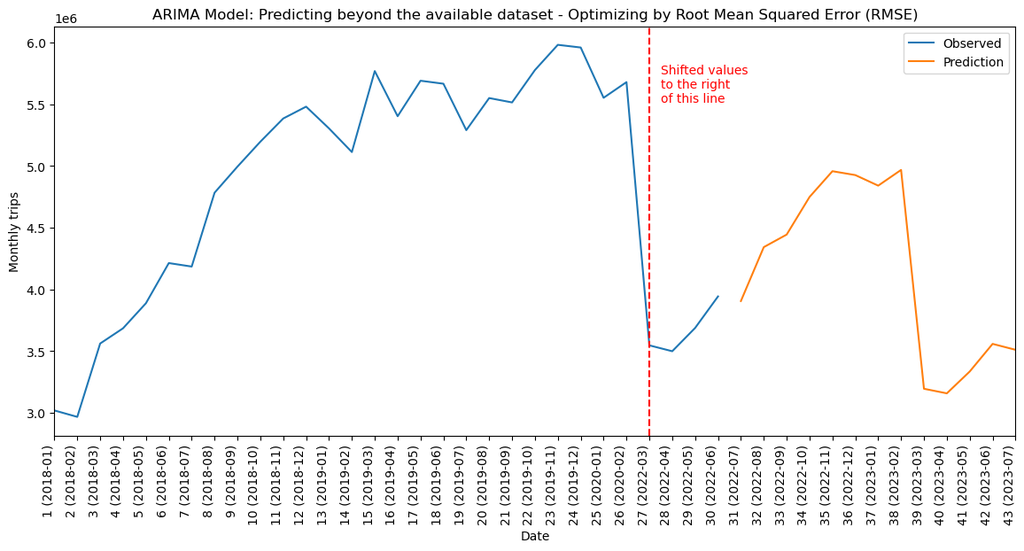

```python
# Identify plot size
fig, ax = plt.subplots(figsize=(14, 6))

# Plot the lines
ax.plot(data['x_label'], data['Observed'], label='Observed')
ax.plot(data['x_label'], data['Prediction'], label='Prediction')

# Set x-axis label, y-axis label, and title
ax.set_xlabel('Date')
ax.set_ylabel('Monthly trips')
ax.set_title('ARIMA Model: Predicting beyond the available dataset - Optimizing by Root Mean Squared Error (RMSE)')

# Add legend
ax.legend()

plt.xticks(rotation=90, ha='right')  # Rotate and slant x-axis labels to the right

# Add a vertical line
ax.axvline(x=26, color='red', linestyle='--')

# Add label for the vertical line
ax.text(26.5, ax.get_ylim()[1]- 0.05 * ax.get_ylim()[1], 'Shifted values\nto the right\nof this line',
        color='red', verticalalignment='top', horizontalalignment='left')

# Adjust spacing before the first tick and after the last tick
plt.margins(x=0)

plt.show()
```

### Approach 2Bi. Optimizing for Bayesian Information Criterion (BIC) for all AR, I, MA combinations

```python
# Identifies the typical ranges of p (autoregressive order), q (moving average order), d (integrated order)
# %%script false # Skips running this code due to long runtime

bic.clear()
order.clear()

p = range(0, 12)
q = range(0, 10)
d = range(0, 2)
s = 12

pdq_combination = list(itertools.product(p, d, q))
```

```python
# %%script false # Skips running this code due to long runtime

# For loop that calculates the BIC for each combination
for pdq in pdq_combination:
    try:
        model = SARIMAX(train_set, order=(10, 1, 5), seasonal_order=(*pdq, s)).fit()
        bic_value = model.bic
        order.append(pdq)
        bic.append(bic_value)
    except:
        continue
```

```python
# %%script false # Skips running this code due to long runtime

# Sort the BIC values from smallest to highest for each combination of p, d, q
results_bic_add = pd.DataFrame(index=order, data=bic, columns=['BIC']).sort_values(by='BIC', ascending=True)
results_bic_add
```

|  | BIC |
| --- | --- |
| (0, 0, 0) | 5.387673e+01 |
| (10, 0, 0) | 8.754969e+01 |
| (9, 0, 2) | 9.091699e+01 |
| (5, 0, 6) | 9.091699e+01 |
| (11, 0, 1) | 9.428428e+01 |
| ... | ... |
| (1, 0, 7) | 2.554340e+08 |
| (0, 0, 3) | 3.238991e+08 |
| (0, 0, 2) | 5.859457e+08 |
| (0, 0, 1) | 6.941049e+08 |
| (1, 0, 0) | 8.199512e+08 |

119 rows × 1 columns

```python
# %%script false # Skips running this code due to long runtime

#Exported the table due to the long time needed to determine the BIC values for all B, Q, D values
results_bic_add.reset_index().to_csv('bic_results_wremoval.csv', index=False) #BIC for loop results
```

```python
# Read the CSV file into a DataFrame
results = pd.read_csv('bic_results_wremoval.csv')
results
```

|  | index | BIC |
| --- | --- | --- |
| 0 | (0, 0, 0) | 5.387673e+01 |
| 1 | (10, 0, 0) | 8.754969e+01 |
| 2 | (9, 0, 2) | 9.091699e+01 |
| 3 | (5, 0, 6) | 9.091699e+01 |
| 4 | (11, 0, 1) | 9.428428e+01 |
| ... | ... | ... |
| 114 | (1, 0, 7) | 2.554340e+08 |
| 115 | (0, 0, 3) | 3.238991e+08 |
| 116 | (0, 0, 2) | 5.859457e+08 |
| 117 | (0, 0, 1) | 6.941049e+08 |
| 118 | (1, 0, 0) | 8.199512e+08 |

119 rows × 2 columns

```python
warnings.filterwarnings('ignore') #Ignores warnings
arima_order = (10, 1, 5) #Based on the ARIMA optimization above
sarima_order = (0, 0 ,0, 12)
sarima_model_fit = SARIMAX(train_set, order=arima_order, seasonal_order=sarima_order).fit()
sarima_model_fit.summary()
```

SARIMAX Results

| Dep. Variable: | count | No. Observations: | 30 |
| --- | --- | --- | --- |
| Model: | SARIMAX(10, 1, 5) | Log Likelihood | 0.000 |
| Date: | Thu, 20 Jul 2023 | AIC | 32.000 |
| Time: | 01:35:18 | BIC | 53.877 |
| Sample: | 01-01-2018 | HQIC | 38.852 |
|  | - 06-01-2020 |  |  |
| Covariance Type: | opg |  |  |

|  | coef | std err | z | P>\|z\| | [0.025 | 0.975] |
| --- | --- | --- | --- | --- | --- | --- |
| ar.L1 | -0.9859 | 5.86e-11 | -1.68e+10 | 0.000 | -0.986 | -0.986 |
| ar.L2 | 2.8563 | 4.39e-13 | 6.51e+12 | 0.000 | 2.856 | 2.856 |
| ar.L3 | 4.1362 | 2.06e-14 | 2.01e+14 | 0.000 | 4.136 | 4.136 |
| ar.L4 | -1.8567 | 2.73e-12 | -6.8e+11 | 0.000 | -1.857 | -1.857 |
| ar.L5 | -6.2985 | 4.64e-09 | -1.36e+09 | 0.000 | -6.299 | -6.299 |
| ar.L6 | -1.8581 | 3.65e-13 | -5.09e+12 | 0.000 | -1.858 | -1.858 |
| ar.L7 | 4.1352 | 4.55e-13 | 9.08e+12 | 0.000 | 4.135 | 4.135 |
| ar.L8 | 2.8565 | 4.4e-14 | 6.49e+13 | 0.000 | 2.857 | 2.857 |
| ar.L9 | -0.9853 | 4.94e-13 | -1.99e+12 | 0.000 | -0.985 | -0.985 |
| ar.L10 | -0.9998 | 1.72e-14 | -5.83e+13 | 0.000 | -1.000 | -1.000 |
| ma.L1 | 2.3590 | -0 | -inf | 0.000 | 2.359 | 2.359 |
| ma.L2 | 1.3620 | -0 | -inf | 0.000 | 1.362 | 1.362 |
| ma.L3 | -1.3624 | -0 | inf | 0.000 | -1.362 | -1.362 |
| ma.L4 | -2.3588 | 7.75e-08 | -3.04e+07 | 0.000 | -2.359 | -2.359 |
| ma.L5 | -0.9998 | -0 | inf | 0.000 | -1.000 | -1.000 |
| sigma2 | 7.182e+04 | -0 | -inf | 0.000 | 7.18e+04 | 7.18e+04 |

| Ljung-Box (L1) (Q): | nan | Jarque-Bera (JB): | nan |
| --- | --- | --- | --- |
| Prob(Q): | nan | Prob(JB): | nan |
| Heteroskedasticity (H): | nan | Skew: | nan |
| Prob(H) (two-sided): | nan | Kurtosis: | nan |

Warnings:  
[1] Covariance matrix calculated using the outer product of gradients (complex-step).  
[2] Covariance matrix is singular or near-singular, with condition number inf. Standard errors may be unstable.

**Interpretation**

**Predicting using the model**

```python
prediction = pd.DataFrame(sarima_model_fit.forecast(len(test_set)))

# Assign the index name and rename it as `date_col`
prediction.index = pd.to_datetime(prediction.index).rename('date_col')

# Display the DataFrame with the assigned index
prediction
```

| date_col | predicted_mean |
| --- | --- |
| 2020-07-01 | 0.0 |
| 2020-08-01 | 0.0 |
| 2020-09-01 | 0.0 |
| 2020-10-01 | 0.0 |
| 2020-11-01 | 0.0 |
| 2020-12-01 | 0.0 |
| 2021-01-01 | 0.0 |

```python
# Calculate MSE
mse = np.mean((np.array(test_set['count']) - np.array(prediction['predicted_mean']))**2)

# Calculate RMSE
rmse = np.sqrt(mse)

# Calculate MAE
mae = np.mean(np.abs(np.array(test_set) - np.array(prediction)))

print("RMSE:", rmse)
print("MSE:", mse)
print("MAE:", mae)
```

```
RMSE: 4245899.417948763
MSE: 18027661867337.645
MAE: 4241221.0
```

```python
mean_val = test_set.mean().item()
stdev = np.sqrt(test_set.var()).item()

print('Mean: %F'  % mean_val)
print('Standard deviation: %F' % stdev)

# print('ADF Statistic: %F' % result[0])
# print('p-value: %F' % result[1])

#Determining the mean squared error
error = np.sqrt(mean_squared_error(test_set, prediction))
print('Error: %F'  % error)
```

```
Mean: 4241221.000000
Standard deviation: 215230.138641
Error: 4245899.417949
```

**Graphing the predictions in the test set period**

```python
## Setting up the table to graph
# Concatenate train_set, test_set, and predictions into a single DataFrame
data = pd.concat([train_set, test_set, prediction], axis=1)
data.columns = ['Train Set', 'Test Set', 'SARIMA Prediction']

# Reset the index
data = data.reset_index()

# Convert the 'date_col' to datetime
data['date_col'] = pd.to_datetime(data['date_col'])

# Add the 'month_interval' column
data['month_interval'] = data.index + 1

# Calculate the next month by adding one month to the previous row
data['month_deseq'] = data['date_col'].apply(lambda x: x if x <= pd.Timestamp('2020-02-01') else x + pd.DateOffset(years=2))

# Modify the DataFrame to include a combined label for rows with month_interval
data['x_label'] = data.apply(lambda row: f"{row['month_interval']} ({row['month_deseq'].strftime('%Y-%m')})" if pd.notnull(row['month_deseq'])
                         else f"{row['month_interval']}", axis=1)

# Display the modified DataFrame
data.head()
```

|  | date_col | Train Set | Test Set | SARIMA Prediction | month_interval | month_deseq | x_label |
| --- | --- | --- | --- | --- | --- | --- | --- |
| 0 | 2018-01-01 | 3020192.0 | NaN | NaN | 1 | 2018-01-01 | 1 (2018-01) |
| 1 | 2018-02-01 | 2968100.0 | NaN | NaN | 2 | 2018-02-01 | 2 (2018-02) |
| 2 | 2018-03-01 | 3562090.0 | NaN | NaN | 3 | 2018-03-01 | 3 (2018-03) |
| 3 | 2018-04-01 | 3685425.0 | NaN | NaN | 4 | 2018-04-01 | 4 (2018-04) |
| 4 | 2018-05-01 | 3888148.0 | NaN | NaN | 5 | 2018-05-01 | 5 (2018-05) |

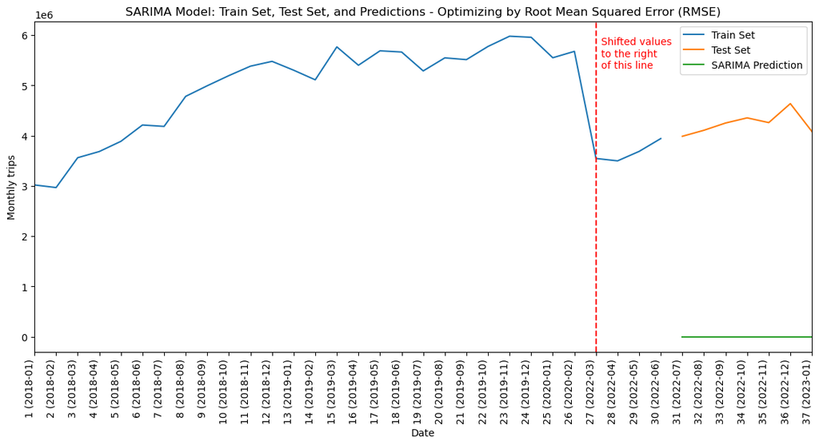

```python
# Identify plot size
fig, ax = plt.subplots(figsize=(14, 6))

# Plot the lines
ax.plot(data['x_label'], data['Train Set'], label='Train Set')
ax.plot(data['x_label'], data['Test Set'], label='Test Set')
ax.plot(data['x_label'], data['SARIMA Prediction'], label='SARIMA Prediction')

# Set x-axis label, y-axis label, and title
ax.set_xlabel('Date')
ax.set_ylabel('Monthly trips')
ax.set_title('SARIMA Model: Train Set, Test Set, and Predictions - Optimizing by Root Mean Squared Error (RMSE)')

# Add legend
ax.legend()

plt.xticks(rotation=90, ha='right')  # Rotate and slant x-axis labels to the right

# Add a vertical line
ax.axvline(x=26, color='red', linestyle='--')

# Add label for the vertical line
ax.text(26.25, ax.get_ylim()[1]- 0.05 * ax.get_ylim()[1], 'Shifted values\nto the right\nof this line',
        color='red', verticalalignment='top', horizontalalignment='left')

# Adjust spacing before the first tick and after the last tick
plt.margins(x=0)

plt.show()
```

**Graphing the predictions in the period beyond training set**

```python
warnings.filterwarnings('ignore') #Ignores warnings

arima_order = (10, 1, 5) #Based on the ARIMA optimization above
sarima_order = (0, 0 ,0, 12)
final_model = SARIMAX(train_set, order=arima_order, seasonal_order=sarima_order).fit()
prediction_future = final_model.predict(len(train_set), len(train_set) + 12) # Build the ARIMA model beyond the available data
```

```python
## Setting up the table to graph
# Concatenate train_set, test_set, and predictions into a single DataFrame
data = pd.concat([train_set, prediction_future], axis=1)
data.columns = ['Observed', 'Prediction']

data.reset_index(drop=False, inplace=True)

data = data.rename(columns={'index': 'date_col'})

# Convert the 'date_col' to datetime
data['date_col'] = pd.to_datetime(data['date_col'])

# Add the 'month_interval' column
data['month_interval'] = data.index + 1

# Calculate the next month by adding one month to the previous row
data['month_deseq'] = data['date_col'].apply(lambda x: x if x <= pd.Timestamp('2020-02-01') else x + pd.DateOffset(years=2))

# Modify the DataFrame to include a combined label for rows with month_interval
data['x_label'] = data.apply(lambda row: f"{row['month_interval']} ({row['month_deseq'].strftime('%Y-%m')})" if pd.notnull(row['month_deseq'])
                         else f"{row['month_interval']}", axis=1)

# Display the modified DataFrame
data.head()
```

|  | date_col | Observed | Prediction | month_interval | month_deseq | x_label |
| --- | --- | --- | --- | --- | --- | --- |
| 0 | 2018-01-01 | 3020192.0 | NaN | 1 | 2018-01-01 | 1 (2018-01) |
| 1 | 2018-02-01 | 2968100.0 | NaN | 2 | 2018-02-01 | 2 (2018-02) |
| 2 | 2018-03-01 | 3562090.0 | NaN | 3 | 2018-03-01 | 3 (2018-03) |
| 3 | 2018-04-01 | 3685425.0 | NaN | 4 | 2018-04-01 | 4 (2018-04) |
| 4 | 2018-05-01 | 3888148.0 | NaN | 5 | 2018-05-01 | 5 (2018-05) |

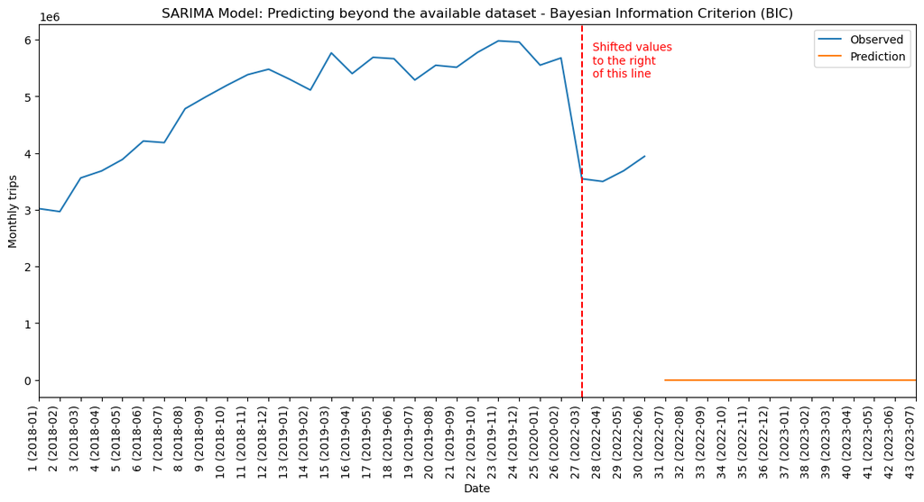

```python
# Identify plot size
fig, ax = plt.subplots(figsize=(14, 6))

# Plot the lines
ax.plot(data['x_label'], data['Observed'], label='Observed')
ax.plot(data['x_label'], data['Prediction'], label='Prediction')

# Set x-axis label, y-axis label, and title
ax.set_xlabel('Date')
ax.set_ylabel('Monthly trips')
ax.set_title('SARIMA Model: Predicting beyond the available dataset - Bayesian Information Criterion (BIC)')

# Add legend
ax.legend()

plt.xticks(rotation=90, ha='right')  # Rotate and slant x-axis labels to the right

# Add a vertical line
ax.axvline(x=26, color='red', linestyle='--')

# Add label for the vertical line
ax.text(26.5, ax.get_ylim()[1]- 0.05 * ax.get_ylim()[1], 'Shifted values\nto the right\nof this line',
        color='red', verticalalignment='top', horizontalalignment='left')

# Adjust spacing before the first tick and after the last tick
plt.margins(x=0)

plt.show()
```

# Conclusions

There are four approaches taken with the time-series modelling:

- Approach 1A. ARIMA Model - Optimizing for Root Mean Squared Error (RMSE)
- Approach 1B. ARIMA Model - Optimizing for Bayesian Information Criterion (BIC)
- Approach 2A. SARIMA Model - Optimizing for Root Mean Squared Error (RMSE)
- Approach 2B. SARIMA Model - Optimizing for Bayesian Information Criterion (BIC)

[output not shown]

Among these four approaches with the reduced test set without the pandemic observations, Approach 1A most accurately predicted the test set results with minimal time.